# Week 1 Application Exercise Key

Prof. Amanda D. Perez, PhD

# AE 1: First Data Viz

## UN Votes Introduction

How do various countries vote in the United Nations General Assembly, how have their voting patterns evolved throughout time, and how similarly or differently do they view certain issues? Answering these questions (at a high level) is the focus of this analysis.

### Packages

We will use the **tidyverse**, **lubridate**, and **scales** packages for data wrangling and visualization, and the **DT** package for interactive display of tabular output, and the **unvotes** package for the data.

```r
library(tidyverse)
library(lubridate)
library(scales)
library(DT)
library(unvotes)
```

### Data

The data we’re using originally come from the **unvotes** package. In the chunk below we modify the data by joining the various data frames provided in the package to help you get started with the analysis.

```r
unvotes <- un_votes %>%
  mutate(country =
           case_when(
             country == "United Kingdom of Great Britain and Northern Ireland" ~ "UK & NI",
             country == "United States of America"                             ~ "US",
             TRUE                                                              ~ country
           )) %>%
  inner_join(un_roll_calls, by = "rcid") %>%
  inner_join(un_roll_call_issues, by = "rcid")
```

## UN voting patterns

Let’s create a data visualisation that displays how the voting record of the UK & NI changed over time on a variety of issues, and compares it to two other countries: US and Turkey.

[figure not shown]

```r
unvotes %>%
  filter(country %in% c("UK & NI", "US", "Turkey")) %>%
  mutate(year = year(date)) %>%
  group_by(country, year, issue) %>%
  summarize(percent_yes = mean(vote == "yes")) %>%
  ggplot(mapping = aes(x = year, y = percent_yes, color = country)) +
  geom_point(alpha = 0.4) +
  geom_smooth(method = "loess", se = FALSE) +
  facet_wrap(~issue) +
  scale_y_continuous(labels = percent) +
  labs(
    title = "Percentage of 'Yes' votes in the UN General Assembly",
    subtitle = "1946 to 2015",
    y = "% Yes",
    x = "Year",
    color = "Country"
  )
```

## YOUR TURN: UN voting patterns

We can easily change which countries are being plotted by changing which countries the code above `filter`s for. **Your task is to change the country name to those you are interested in.**

Note that the country name should be spelled and capitalized exactly the same way as it appears in the data. See the Appendix for a list of the countries in the data.

## Appendix

Below is a list of countries in the dataset:

|  | country |
| --- | --- |
| 1 | Afghanistan |
| 2 | Albania |
| 3 | Algeria |
| 4 | Andorra |
| 5 | Angola |
| 6 | Antigua &amp; Barbuda |
| 7 | Argentina |
| 8 | Armenia |
| 9 | Australia |
| 10 | Austria |

[output cut: 190 more lines]

## ANSWER: Any countries work, I selected Argentina, Peru, & Mexico

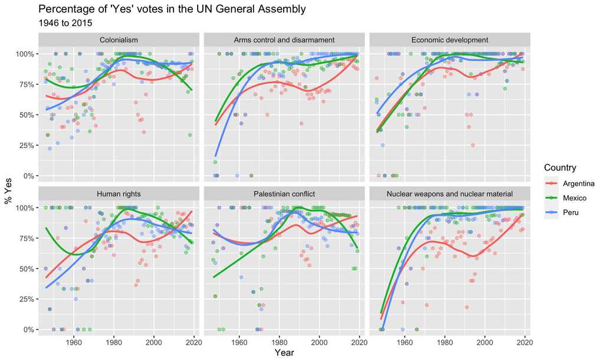

```r
unvotes %>%
  filter(country %in% c("Argentina", "Peru", "Mexico")) %>%
  mutate(year = year(date)) %>%
  group_by(country, year, issue) %>%
  summarize(percent_yes = mean(vote == "yes")) %>%
  ggplot(mapping = aes(x = year, y = percent_yes, color = country)) +
  geom_point(alpha = 0.4) +
  geom_smooth(method = "loess", se = FALSE) +
  facet_wrap(~issue) +
  scale_y_continuous(labels = percent) +
  labs(
    title = "Percentage of 'Yes' votes in the UN General Assembly",
    subtitle = "1946 to 2015",
    y = "% Yes",
    x = "Year",
    color = "Country"
  )
```

# AE 2: Bechdel Test

In this mini analysis we work with the data used in the FiveThirtyEight story titled [“The Dollar-And-Cents Case Against Hollywood’s Exclusion of Women”](https://fivethirtyeight.com/features/the-dollar-and-cents-case-against-hollywoods-exclusion-of-women/).

**Your task is to fill in the blanks denoted by `___`.**

## Data and packages

We start with loading the packages we’ll use.

```r
library(fivethirtyeight)
library(tidyverse)
```

The dataset contains information on 1794 movies released between 1970 and 2013. However we’ll focus our analysis on movies released between 1990 and 2013.

```r
bechdel90_13 <- bechdel %>%
  filter(between(year, 1990, 2013))
```

## ANSWER: using nrow(bechdel90_13) to get the number of entries

There are 1615 such movies.

The financial variables we’ll focus on are the following:

- `budget_2013`: Budget in 2013 inflation adjusted dollars
- `domgross_2013`: Domestic gross (US) in 2013 inflation adjusted dollars
- `intgross_2013`: Total International (i.e., worldwide) gross in 2013 inflation adjusted dollars

And we’ll also use the `binary` and `clean_test` variables for **grouping**.

## Analysis

Let’s take a look at how median budget and gross vary by whether the movie passed the Bechdel test, which is stored in the `binary` variable.

```r
bechdel90_13 %>%
  group_by(binary) %>%
  summarise(med_budget = median(budget_2013),
            med_domgross = median(domgross_2013, na.rm = TRUE),
            med_intgross = median(intgross_2013, na.rm = TRUE))
```

```
## # A tibble: 2 x 4
##   binary med_budget med_domgross med_intgross
##   <chr>       <dbl>        <dbl>        <dbl>
## 1 FAIL    48385984.    57318606.    104475669
## 2 PASS    31070724     45330446.     80124349
```

Next, let’s take a look at how median budget and gross vary by a more detailed indicator of the Bechdel test result. This information is stored in the `clean_test` variable, which takes on the following values:

- `ok` = passes test
- `dubious`
- `men` = women only talk about men
- `notalk` = women don’t talk to each other
- `nowomen` = fewer than two women

## ANSWER: group_by(clean_test)

```r
bechdel90_13 %>%
  group_by(clean_test) %>%
  summarise(med_budget = median(budget_2013),
            med_domgross = median(domgross_2013, na.rm = TRUE),
            med_intgross = median(intgross_2013, na.rm = TRUE))
```

```
## # A tibble: 5 x 4
##   clean_test med_budget med_domgross med_intgross
##   <ord>           <dbl>        <dbl>        <dbl>
## 1 nowomen     43373066     44891296.    89509349
## 2 notalk      56570084.    63890455    123102194
## 3 men         39737690.    56392786     99578022.
## 4 dubious     35790994     49173429     89883201
## 5 ok          31070724     45330446.    80124349
```

In order to evaluate how return on investment varies among movies that pass and fail the Bechdel test, we’ll first create a new variable called `roi` as the ratio of the gross to budget.

```r
bechdel90_13 <- bechdel90_13 %>%
  mutate(roi = (intgross_2013 + domgross_2013) / budget_2013)
```

Let’s see which movies have the highest return on investment.

```r
bechdel90_13 %>%
  arrange(desc(roi)) %>%
  select(title, roi, year)
```

```
## # A tibble: 1,615 x 3
##    title                     roi  year
##    <chr>                   <dbl> <int>
##  1 Paranormal Activity      671.  2007
##  2 The Blair Witch Project  648.  1999
##  3 El Mariachi              583.  1992
##  4 Clerks.                  258.  1994
##  5 In the Company of Men    231.  1997
##  6 Napoleon Dynamite        227.  2004
##  7 Once                     190.  2006
##  8 The Devil Inside         155.  2012
##  9 Primer                   142.  2004
## 10 Fireproof                134.  2008
## # … with 1,605 more rows
```

Below is a visualization of the return on investment by test result, however it’s difficult to see the distributions due to a few extreme observations.

## Answer: Label y axis. I used “ROI”

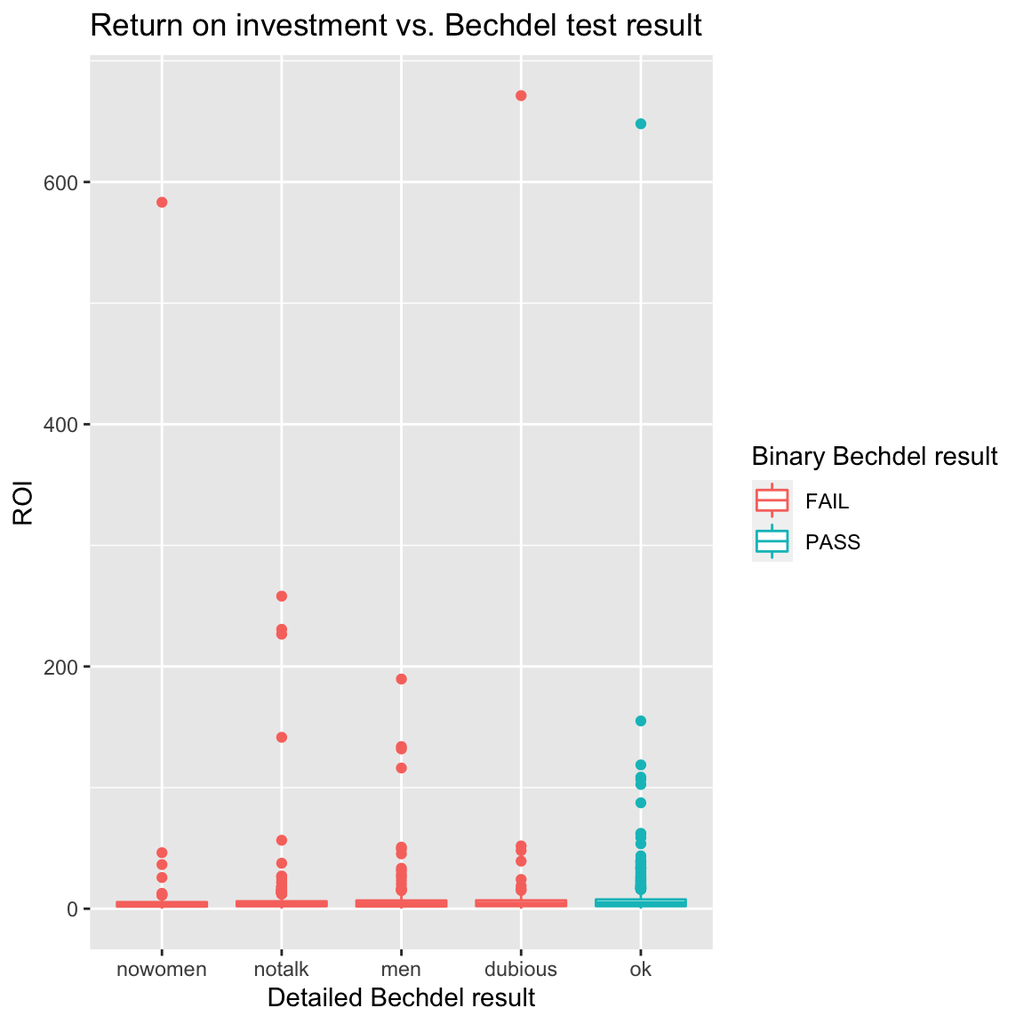

```r
ggplot(data = bechdel90_13,
       mapping = aes(x = clean_test, y = roi, color = binary)) +
  geom_boxplot() +
  labs(title = "Return on investment vs. Bechdel test result",
       x = "Detailed Bechdel result",
       y = "ROI",
       color = "Binary Bechdel result")
```

What are those movies with *very* high returns on investment?

```r
bechdel90_13 %>%
  filter(roi > 400) %>%
  select(title, budget_2013, domgross_2013, year)
```

```
## # A tibble: 3 x 4
##   title                   budget_2013 domgross_2013  year
##   <chr>                         <int>         <dbl> <int>
## 1 Paranormal Activity          505595     121251476  2007
## 2 The Blair Witch Project      839077     196538593  1999
## 3 El Mariachi                   11622       3388636  1992
```

## ANSWER: Any small value that provides a better view is acceptable. I used 8. Filtering the data could have been done in a variety of different ways. I used filtering within the ggplot data argument (see below). The subtitle also needed to be updated to relevant text. Finally, I updated the coord_cartesian to the same value (8) for a better view but this part was not mandatory.

Zooming in on the movies with `roi < 8` provides a better view of how the medians across the categories compare:

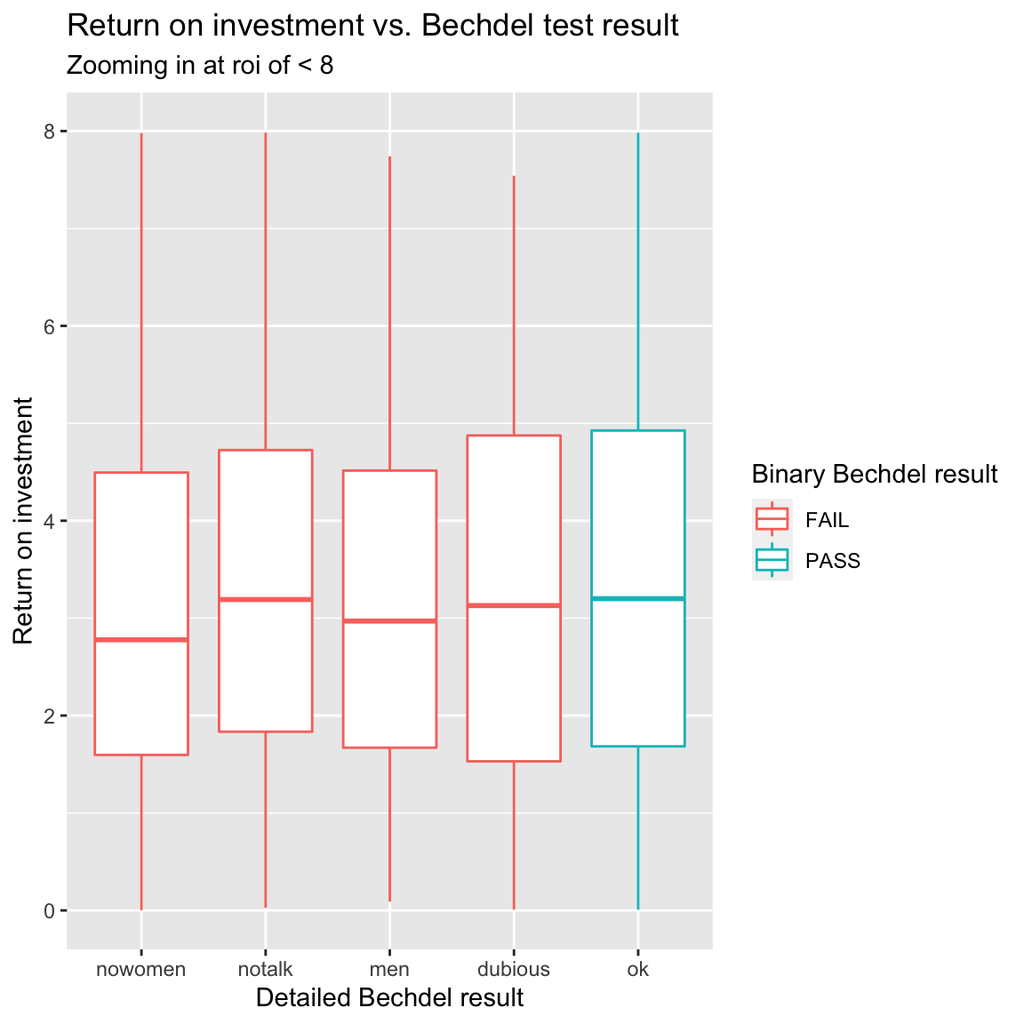

```r
ggplot(data = bechdel90_13 %>% filter(roi < 8), mapping = aes(x = clean_test, y = roi, color = binary)) +
  geom_boxplot() +
  labs(title = "Return on investment vs. Bechdel test result",
       subtitle = "Zooming in at roi of < 8", # Something about zooming in to a certain level
       x = "Detailed Bechdel result",
       y = "Return on investment",
       color = "Binary Bechdel result") +
  coord_cartesian(ylim = c(0, 8))
```

## References

1. David Robinson (2017). unvotes: United Nations General Assembly Voting Data. R package version 0.2.0.
2. Erik Voeten “Data and Analyses of Voting in the UN General Assembly” Routledge Handbook of International Organization, edited by Bob Reinalda (published May 27, 2013).
3. Much of the analysis has been modeled on the examples presented in the [unvotes package vignette](https://cran.r-project.org/web/packages/unvotes/vignettes/unvotes.html).
4. Mine Çetinkaya-Rundel; Creator